# 카테고리별 소분류 연관분석

올림푸스

2020-04-27

```r
# 데이터 로딩
load("~/Documents/R/R_workspace/easy_r/Lotte_data/train_order.rda")
load("~/Documents/R/R_workspace/easy_r/Lotte_data/new_master0324.rda")
load("~/Documents/R/R_workspace/easy_r/Lotte_data/new_product0324.rda")
```

# 대대분류(CN_our)별 소분류 연관분석

- 각 분류별 소분류 항목들의 연관분석을 통해 어떤 상품들이 함께 팔리는지 경향성을 파악한다.
- 제품 상세페이지에 연관성이 높은 상품을 추천함으로써 구매율을 높이는 것을 목적으로 한다.
- 총 10개의 대대분류별 소분류 항목의 연관분석을 수행하고, 연관규칙이 없는 대대분류 C9와 C10은 분석하지 않는다.

대대분류는 다음과 같다. C1 : 전자제품 C2 : 리빙 C3 : 식품 C4 : 스포츠 C5 : 패션 C6 : 뷰티 C7 : 유아용품 C8 : 취미용품 C9 : 사무용품 C10: 상품권

- 연관분석 지표
1. Support (지지도) :
- 전체 거래에서 X, Y를 동시에 포함한 거래 비율
- P(X∩Y) = ( X,Y를 동시에 포함하는 거래수) / (전체 거래수)
2. Confidence (신뢰도) :
- X를 구입한 거래 중 Y를 같이 구입한 비율
- 신뢰도가 높을수록 유용한 규칙일 가능성이 높다.
- P(X∩ Y) / P(X) = (X,Y를 동시에 포함하는 거래수) / (품목 X를 포함하는 거래수)
3. Lift (향상도) :
- X를 구매한 사람이 Y를 구매할 확률과 X의 구매와 상관없이 Y를 구매할 확률의 비율
- 연관규칙의 신뢰도/지지도
- Lift(향상도)가 1이면, 두 상품이 서로 독립적인 관계
- Lift가 > 1이면, 양의 상관관계
- Lift가 < 1면, 음의 상관관계

# 1. 전자제품 카테고리 소분류 연관분석

```r
# 데이터 전처리
library(dplyr)
a <- train_order
a <- inner_join(a, df_product, by=c('PD_C', 'CN_our'))
a <- inner_join(a, df_master, by=c('CLAC_C', 'CN_our'))

df <- a %>%
    filter(CN_our == 'C1')

clac3 <- df[c('CLAC3_NM', 'CLNT_ID')]

# 소분류(CLAC_3) 품목 개수 확인
length(unique(clac3$CLAC3_NM))
```

```
## [1] 96
```

```r
# 고객 id별로 구매 항목 모으기
clac3_list <- split(clac3$CLAC3_NM, clac3$CLNT_ID)

# 중복 제거하고 transaction으로 변환
library(arules)
clac3_list <- sapply(clac3_list, unique)
clac3_list <- as(clac3_list, 'transactions')

# 연관규칙 생성 - 지지도 0.0001 이상, 신뢰도 0.3이상
clac3_rule <- apriori(clac3_list, parameter = list(support = 0.0001, confidence = 0.3, minlen = 2))
```

```
## Apriori
##
## Parameter specification:
##  confidence minval smax arem  aval originalSupport maxtime support minlen
##         0.3    0.1    1 none FALSE            TRUE       5  0.0001      2
##  maxlen target   ext
##      10  rules FALSE
##
## Algorithmic control:
##  filter tree heap memopt load sort verbose
##     0.1 TRUE TRUE  FALSE TRUE    2    TRUE
##
## Absolute minimum support count: 4
##
## set item appearances ...[0 item(s)] done [0.00s].
## set transactions ...[96 item(s), 46478 transaction(s)] done [0.00s].
## sorting and recoding items ... [93 item(s)] done [0.00s].
## creating transaction tree ... done [0.01s].
## checking subsets of size 1 2 3 4 done [0.00s].
## writing ... [54 rule(s)] done [0.00s].
## creating S4 object  ... done [0.00s].
```

```r
summary(clac3_rule)
```

```
## set of 54 rules
##
## rule length distribution (lhs + rhs):sizes
##  2  3
##  2 52
##
##    Min. 1st Qu.  Median    Mean 3rd Qu.    Max.
##   2.000   3.000   3.000   2.963   3.000   3.000
##
## summary of quality measures:
##     support            confidence          lift            count
##  Min.   :0.0001076   Min.   :0.3000   Min.   : 2.525   Min.   : 5.000
##  1st Qu.:0.0001076   1st Qu.:0.3370   1st Qu.: 3.246   1st Qu.: 5.000
##  Median :0.0001291   Median :0.3944   Median : 4.862   Median : 6.000
##  Mean   :0.0001626   Mean   :0.4334   Mean   :13.840   Mean   : 7.556
##  3rd Qu.:0.0001721   3rd Qu.:0.5000   3rd Qu.:22.412   3rd Qu.: 8.000
##  Max.   :0.0004949   Max.   :1.0000   Max.   :88.361   Max.   :23.000
##
## mining info:
##        data ntransactions support confidence
##  clac3_list         46478  0.0001        0.3
```

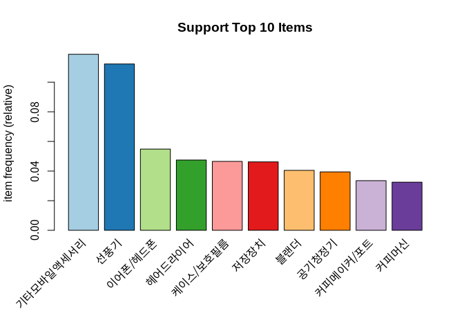

```r
# 지지도 상위 10개 막대그래프
library(RColorBrewer)
itemFrequencyPlot(clac3_list,
                  topN = 10,
                  main = 'Support Top 10 Items',
                  col = brewer.pal(12,'Paired'))
```

```r
# 향상도 높은순으로 내림차순하기
inspect(sort(clac3_rule, by = 'lift'))
```

```
##      lhs                                         rhs
## [1]  {리모컨/액세서리}                        => {UHD}
## [2]  {모니터,스피커}                          => {마우스}
## [3]  {스피커,키보드}                          => {마우스}
## [4]  {리모컨/액세서리}                        => {LED}
## [5]  {양문형냉장고,전기밥솥}                  => {일반세탁기}
## [6]  {모니터,저장장치}                        => {마우스}
## [7]  {인덕션/가스레인지,일반형냉장고}         => {일반세탁기}
## [8]  {인덕션/가스레인지,일반세탁기}           => {일반형냉장고}
## [9]  {마우스,스피커}                          => {키보드}
## [10] {일반형냉장고,전기밥솥}                  => {일반세탁기}
## [11] {오븐/전자레인지,일반세탁기}             => {일반형냉장고}
## [12] {마우스,모니터}                          => {스피커}
## [13] {오븐/전자레인지,일반형냉장고}           => {일반세탁기}
## [14] {일반세탁기,전기밥솥}                    => {일반형냉장고}
```

[output cut: 95 more lines]

```r
# 연관규칙 2그룹으로 분리하기
C1_1 <- clac3_rule[c(3:8,10,17:25,31,34,35,38,43,44,47,53,54), ]           # 컴퓨터 용품
C1_2 <- clac3_rule[c(1,2,9,11:16,26:30,32,33,36,37,39:42,45,46,48:52), ]   # 일반가전
```

## 연관분석 시각화 -1

[output not shown]

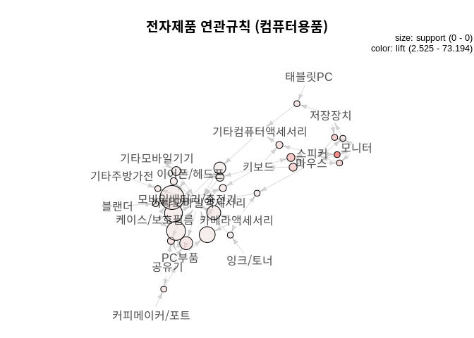

```r
library(arulesViz)
plot(C1_1, method = "graph",
     control = list(type = 'items'),
     main = '전자제품 연관규칙 (컴퓨터용품)',
     vertex.label.cex = 0.7,
     edge.arrow.size = 0.3)
```

## 연관분석 시각화 -2

[output not shown]

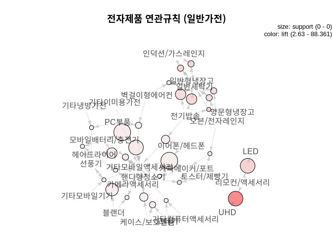

```r
plot(C1_2, method = "graph",
     control = list(type = 'items'),
     main = '전자제품 연관규칙 (일반가전)',
     vertex.label.cex = 0.7,
     edge.arrow.size = 0.3)
```

## 인사이트

1. 모니터, 키보드, 마우스 등 PC부품을 동시에 사는 패턴을 보임
2. 에어컨, 냉장고, 세탁기 등 대형 가전들을 동시에 사는 패턴을 보임
3. 전자레인지, 토스터, 커피포트 등 주방 가전들을 같이 사는 패턴을 보임
4. 전자제품에서 지지도가 가장 높은 소분류 항목은 기타모바일액세서리인데, 그 안에서 매출이 가장 높은 제품은 에어팟 케이스이다.

** 활용방안 : 연관성이 높은 제품들을 제품 상세페이지에 함께 추천하여 관심을 끈다.

# 2. 리빙 카테고리 소분류 연관분석

```r
# 데이터 전처리
library(dplyr)

a <- train_order
a <- inner_join(a, df_product, by=c('PD_C', 'CN_our'))
a <- inner_join(a, df_master, by=c('CLAC_C', 'CN_our'))

df <- a %>%
  filter(CN_our == 'C2')

clac3 <- df[c('CLAC3_NM', 'CLNT_ID')]

# 소분류(CLAC_3) 품목 개수 확인
length(unique(clac3$CLAC3_NM))
```

```
## [1] 154
```

```r
# 154

# 고객 id별로 구매 항목 모으기
clac3_list <- split(clac3$CLAC3_NM, clac3$CLNT_ID)

# 중복 제거하고 transaction으로 변환
library(arules)
clac3_list <- sapply(clac3_list, unique)
clac3_list <- as(clac3_list, 'transactions')

# 연관규칙 생성 - 지지도 0.001 이상, 신뢰도 0.3이상
clac3_rule <- apriori(clac3_list, parameter = list(support = 0.001, confidence = 0.3, minlen = 2))  # 48 rules
```

```
## Apriori
##
## Parameter specification:
##  confidence minval smax arem  aval originalSupport maxtime support minlen
##         0.3    0.1    1 none FALSE            TRUE       5   0.001      2
##  maxlen target   ext
##      10  rules FALSE
##
## Algorithmic control:
##  filter tree heap memopt load sort verbose
##     0.1 TRUE TRUE  FALSE TRUE    2    TRUE
##
## Absolute minimum support count: 88
##
## set item appearances ...[0 item(s)] done [0.00s].
## set transactions ...[154 item(s), 88964 transaction(s)] done [0.01s].
## sorting and recoding items ... [127 item(s)] done [0.00s].
## creating transaction tree ... done [0.02s].
## checking subsets of size 1 2 3 4 done [0.00s].
## writing ... [48 rule(s)] done [0.00s].
## creating S4 object  ... done [0.00s].
```

```r
# 향상도 높은순으로 내림차순하기
inspect(sort(clac3_rule, by = 'lift'))
```

```
##      lhs
## [1]  {커튼링/커튼봉/부속품}                          =>
## [2]  {포크/나이프}                                   =>
## [3]  {밥공기,접시}                                   =>
## [4]  {접시,찬기/종지}                                =>
## [5]  {대접/볼,찬기/종지}                             =>
## [6]  {기타정리용품,기타주방정리용품/소모품}          =>
## [7]  {대접/볼,밥공기}                                =>
## [8]  {찬기/종지}                                     =>
## [9]  {국자/뒤지개/주걱}                              =>
## [10] {성인이불/이불커버,성인침구속통/솜}             =>
## [11] {기타조리도구,주방선반/걸이대}                  =>
## [12] {성인침구속통/솜,성인패드/스프레드}             =>
## [13] {밥공기}                                        =>
## [14] {기타주방정리용품/소모품,주방선반/걸이대}       =>
```

[output cut: 83 more lines]

```r
summary(clac3_rule)
```

```
## set of 48 rules
##
## rule length distribution (lhs + rhs):sizes
##  2  3
##  7 41
##
##    Min. 1st Qu.  Median    Mean 3rd Qu.    Max.
##   2.000   3.000   3.000   2.854   3.000   3.000
##
## summary of quality measures:
##     support           confidence          lift            count
##  Min.   :0.001012   Min.   :0.3040   Min.   : 3.981   Min.   :  90.0
##  1st Qu.:0.001135   1st Qu.:0.3346   1st Qu.: 5.763   1st Qu.: 101.0
##  Median :0.001169   Median :0.3617   Median : 7.378   Median : 104.0
##  Mean   :0.002052   Mean   :0.3852   Mean   : 8.653   Mean   : 182.5
##  3rd Qu.:0.001717   3rd Qu.:0.4057   3rd Qu.: 8.970   3rd Qu.: 152.8
##  Max.   :0.023358   Max.   :0.6392   Max.   :25.000   Max.   :2078.0
##
## mining info:
##        data ntransactions support confidence
##  clac3_list         88964   0.001        0.3
```

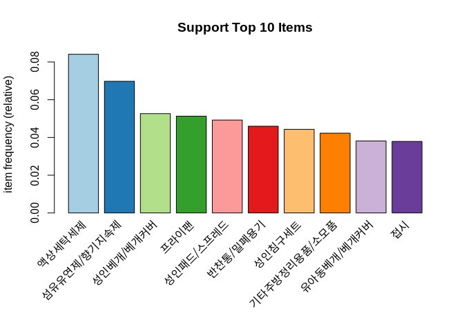

```r
# 지지도 상위 10개 막대그래프
library(RColorBrewer)
itemFrequencyPlot(clac3_list,
                  topN = 10,
                  main = 'Support Top 10 Items',
                  col = brewer.pal(12,'Paired'))
```

```r
# 연관규칙 2그룹으로 분리하기
C2_1 <- clac3_rule[c(2,7,12:23,30:32,35,41,42,47,48), ]      # 침구류, 세탁용품
C2_2 <- clac3_rule[c(1,3:6,8:11,24:29,33,34,36:40,43:46), ]  # 주방용품
```

## 연관분석 시각화 -1

[output not shown]

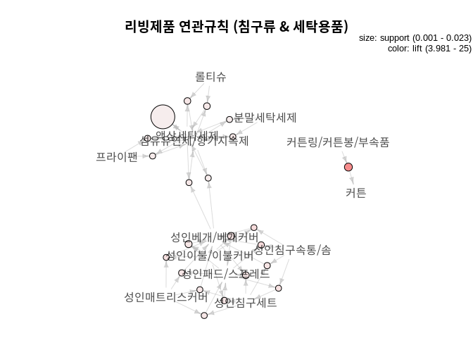

```r
library(arulesViz)
plot(C2_1, method = "graph",
     control = list(type = 'items'),
     main = '리빙제품 연관규칙 (침구류 & 세탁용품)',
     vertex.label.cex = 0.7,
     edge.arrow.size = 0.3)
```

## 연관분석 시각화 -2

[output not shown]

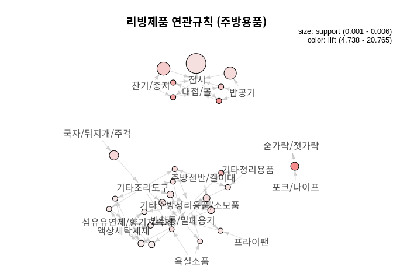

```r
plot(C2_2, method = "graph",
     control = list(type = 'items'),
     main = '리빙제품 연관규칙 (주방용품)',
     vertex.label.cex = 0.7,
     edge.arrow.size = 0.3)
```

## 인사이트

- 주방용품
1. 식기(숟가락, 젓가락, 포크, 나이프) 동시에 사는 패턴을 보임
2. 밥공기, 접시, 종지 등 다양한 종류의 접시를 동시에 사는 패턴을 보임
3. 조리도구(국자, 뒤지개, 주걱)을 동시에 사는 패턴을 보임
- 침구류 및 세탁용품
1. 베개, 이불, 매트리스 등 침구류를 동시에 사는 패턴을 보임
2. 섬유유연제, 세탁세제, 향기지속제 등 세탁용품을 동시에 사는 패턴을 보임

** 활용방안 : 연관성이 높은 제품들을 제품 상세페이지에 함께 추천하여 관심을 끈다.

# 3. 식품 카테고리 소분류 연관분석

```r
# 데이터 전처리
library(dplyr)

a <- train_order
a <- inner_join(a, df_product, by=c('PD_C', 'CN_our'))
a <- inner_join(a, df_master, by=c('CLAC_C', 'CN_our'))

df <- a %>%
    filter(CN_our == 'C3')

clac3 <- df[c('CLAC3_NM', 'CLNT_ID')]

# 소분류(CLAC_3) 품목 개수 확인
length(unique(clac3$CLAC3_NM))
```

```
## [1] 88
```

```r
# 고객 id별로 구매 항목 모으기
clac3_list <- split(clac3$CLAC3_NM, clac3$CLNT_ID)

# 중복 제거하고 transaction으로 변환
library(arules)
clac3_list <- sapply(clac3_list, unique)
clac3_list <- as(clac3_list, 'transactions')

# 연관규칙 생성 - 지지도 0.0003 이상, 신뢰도 0.3이상
clac3_rule <- apriori(clac3_list, parameter = list(support = 0.0003, confidence = 0.3, minlen = 2))
```

```
## Apriori
##
## Parameter specification:
##  confidence minval smax arem  aval originalSupport maxtime support minlen
##         0.3    0.1    1 none FALSE            TRUE       5  0.0003      2
##  maxlen target   ext
##      10  rules FALSE
##
## Algorithmic control:
##  filter tree heap memopt load sort verbose
##     0.1 TRUE TRUE  FALSE TRUE    2    TRUE
##
## Absolute minimum support count: 19
##
## set item appearances ...[0 item(s)] done [0.00s].
## set transactions ...[88 item(s), 65918 transaction(s)] done [0.01s].
## sorting and recoding items ... [73 item(s)] done [0.00s].
## creating transaction tree ... done [0.01s].
## checking subsets of size 1 2 3 4 done [0.00s].
## writing ... [30 rule(s)] done [0.00s].
## creating S4 object  ... done [0.00s].
```

```r
summary(clac3_rule)
```

```
## set of 30 rules
##
## rule length distribution (lhs + rhs):sizes
##  2  3
##  3 27
##
##    Min. 1st Qu.  Median    Mean 3rd Qu.    Max.
##     2.0     3.0     3.0     2.9     3.0     3.0
##
## summary of quality measures:
##     support            confidence          lift            count
##  Min.   :0.0003034   Min.   :0.3030   Min.   : 2.389   Min.   : 20.00
##  1st Qu.:0.0003224   1st Qu.:0.3271   1st Qu.: 4.142   1st Qu.: 21.25
##  Median :0.0003793   Median :0.3493   Median : 4.616   Median : 25.00
##  Mean   :0.0005274   Mean   :0.3940   Mean   :15.039   Mean   : 34.77
##  3rd Qu.:0.0005916   3rd Qu.:0.4258   3rd Qu.:23.597   3rd Qu.: 39.00
##  Max.   :0.0032009   Max.   :0.9130   Max.   :66.789   Max.   :211.00
##
## mining info:
##        data ntransactions support confidence
##  clac3_list         65918  0.0003        0.3
```

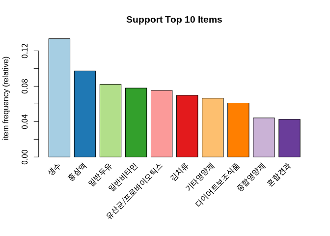

```r
# 지지도 상위 10개 막대그래프
library(RColorBrewer)
itemFrequencyPlot(clac3_list,
                  topN = 10,
                  main = 'Support Top 10 Items',
                  col = brewer.pal(12,'Paired'))
```

```r
# 향상도 높은순으로 내림차순하기
inspect(sort(clac3_rule, by = 'lift'))
```

```
##      lhs                                        rhs                support
## [1]  {아몬드,캐슈넛}                         => {호두}             0.0003185776
## [2]  {캐슈넛,호두}                           => {아몬드}           0.0003185776
## [3]  {아몬드,혼합견과}                       => {호두}             0.0005916442
## [4]  {기타견과류,아몬드}                     => {호두}             0.0005916442
## [5]  {호두,혼합견과}                         => {아몬드}           0.0005916442
## [6]  {기타견과류,호두}                       => {아몬드}           0.0005916442
## [7]  {캐슈넛}                                => {아몬드}           0.0006523256
## [8]  {호두}                                  => {아몬드}           0.0032009466
## [9]  {발포비타민}                            => {일반비타민}       0.0004095998
## [10] {다이어트보조식품,칼슘/미네랄}          => {기타영양제}       0.0003489184
## [11] {루테인,자연유래영양제}                 => {기타영양제}       0.0003337480
## [12] {기타냉동간편식,혼합즙}                 => {다이어트보조식품} 0.0003034073
## [13] {다이어트보조식품,자연유래영양제}       => {기타영양제}       0.0003944294
## [14] {루테인,칼슘/미네랄}                    => {일반비타민}       0.0003640887
```

[output cut: 47 more lines]

## 연관분석 시각화

[output not shown]

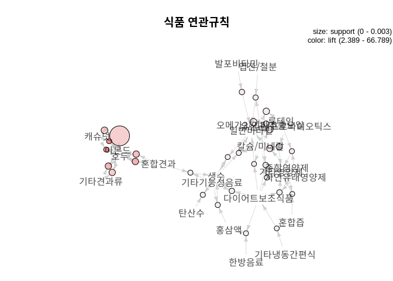

```r
library(arulesViz)
plot(clac3_rule, method = "graph",
     control = list(type = 'items'),
     main = '식품 연관규칙',
     vertex.label.cex = 0.7,
     edge.arrow.size = 0.3)
```

## 인사이트

1. 호두, 캐슈넛, 아몬드 등 다양한 종류의 견과류를 동시에 사는 패턴을 보임
2. 영양제를 사는 고객들은 영양제만 구매하는 패턴을 보이며 다양한 종류의 영양제를 함께 구매함
- 영양제 간 서로 연관성이 높고 건강기능식품에 대한 관심이 증대함에 따라 수요가 증가했을 것으로 추측됨
3. 식품 내에서 지지도 순으로 보면 일반비타민 항목이 4위인데, 그중 고려은단 매출이 가장 높고 판매량도 가장 높다.

** 활용방안 : 연관성이 높은 제품들을 제품 상세페이지에 함께 추천하여 관심을 끈다.

# 4. 스포츠 카테고리 소분류 연관분석

```r
# 데이터 전처리
library(dplyr)

a <- train_order
a <- inner_join(a, df_product, by=c('PD_C', 'CN_our'))
a <- inner_join(a, df_master, by=c('CLAC_C', 'CN_our'))

df <- a %>%
    filter(CN_our == 'C4')

clac3 <- df[c('CLAC3_NM', 'CLNT_ID')]

# 소분류(CLAC_3) 품목 개수 확인
length(unique(clac3$CLAC3_NM))
```

```
## [1] 53
```

```r
# 고객 id별로 구매 항목 모으기
clac3_list <- split(clac3$CLAC3_NM, clac3$CLNT_ID)

# 중복 제거하고 transaction으로 변환
library(arules)
clac3_list <- sapply(clac3_list, unique)
clac3_list <- as(clac3_list, 'transactions')

# 연관규칙 생성 - 지지도 0.002 이상, 신뢰도 0.3이상
clac3_rule <- apriori(clac3_list, parameter = list(support = 0.002, confidence = 0.3, minlen = 2))
```

```
## Apriori
##
## Parameter specification:
##  confidence minval smax arem  aval originalSupport maxtime support minlen
##         0.3    0.1    1 none FALSE            TRUE       5   0.002      2
##  maxlen target   ext
##      10  rules FALSE
##
## Algorithmic control:
##  filter tree heap memopt load sort verbose
##     0.1 TRUE TRUE  FALSE TRUE    2    TRUE
##
## Absolute minimum support count: 167
##
## set item appearances ...[0 item(s)] done [0.00s].
## set transactions ...[53 item(s), 83965 transaction(s)] done [0.01s].
## sorting and recoding items ... [43 item(s)] done [0.00s].
## creating transaction tree ... done [0.02s].
## checking subsets of size 1 2 3 4 done [0.00s].
## writing ... [24 rule(s)] done [0.00s].
## creating S4 object  ... done [0.00s].
```

```r
summary(clac3_rule)
```

```
## set of 24 rules
##
## rule length distribution (lhs + rhs):sizes
##  2  3
##  7 17
##
##    Min. 1st Qu.  Median    Mean 3rd Qu.    Max.
##   2.000   2.000   3.000   2.708   3.000   3.000
##
## summary of quality measures:
##     support           confidence          lift            count
##  Min.   :0.002191   Min.   :0.3037   Min.   : 1.726   Min.   :184.0
##  1st Qu.:0.002310   1st Qu.:0.3150   1st Qu.: 2.417   1st Qu.:194.0
##  Median :0.002489   Median :0.3351   Median : 4.457   Median :209.0
##  Mean   :0.003286   Mean   :0.3594   Mean   : 5.270   Mean   :275.9
##  3rd Qu.:0.003924   3rd Qu.:0.3704   3rd Qu.: 5.906   3rd Qu.:329.5
##  Max.   :0.007062   Max.   :0.6730   Max.   :18.373   Max.   :593.0
##
## mining info:
##        data ntransactions support confidence
##  clac3_list         83965   0.002        0.3
```

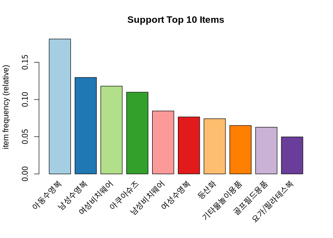

```r
# 지지도 상위 10개 막대그래프
library(RColorBrewer)
itemFrequencyPlot(clac3_list,
                  topN = 10,
                  main = 'Support Top 10 Items',
                  col = brewer.pal(12,'Paired'))
```

```r
inspect(sort(clac3_rule, by = 'lift'))
```

```
##      lhs                              rhs              support     confidence
## [1]  {물안경,여성수영복}           => {수영모자}       0.002322396 0.3779070
## [2]  {수영모자,여성수영복}         => {물안경}         0.002322396 0.3469751
## [3]  {골프연습장비,골프패션잡화}   => {골프필드용품}   0.002548681 0.6729560
## [4]  {골프연습장비,골프필드용품}   => {골프패션잡화}   0.002548681 0.4572650
## [5]  {골프장갑}                    => {골프필드용품}   0.002905973 0.4526902
## [6]  {골프가방}                    => {골프필드용품}   0.002274757 0.3708738
## [7]  {골프공}                      => {골프필드용품}   0.003227535 0.3702186
## [8]  {물안경,여성수영복}           => {기타물놀이용품} 0.002191389 0.3565891
## [9]  {골프연습장비}                => {골프필드용품}   0.005573751 0.3379061
## [10] {물안경,수영모자}             => {여성수영복}     0.002322396 0.4012346
## [11] {골프화}                      => {골프필드용품}   0.004085035 0.3152574
## [12] {물안경,아동수영복}           => {기타물놀이용품} 0.002274757 0.3036566
## [13] {수영모자}                    => {여성수영복}     0.006693265 0.3254198
## [14] {기타물놀이용품,물안경}       => {여성수영복}     0.002191389 0.3118644
```

[output cut: 35 more lines]

## 연관분석 시각화

[output not shown]

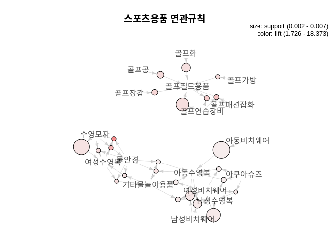

```r
library(arulesViz)
plot(clac3_rule, method = "graph",
     control = list(type = 'items'),
     main = '스포츠용품 연관규칙',
     vertex.label.cex = 0.7,
     edge.arrow.size = 0.3)
```

## 인사이트

1. 아쿠아용품(수영복, 수영모, 물안경 등)을 동시에 구매하는 패턴을 보임
2. 골프용품(골프가방, 골프공 등)을 동시에 구매하는 패턴을 보임

** 활용방안 : 연관성이 높은 제품들을 제품 상세페이지에 함께 추천하여 관심을 끈다.